# Logistic Regression

## Model in order to predict if a customer will accept a loan offer from UniversalBank

## Alfonso Esqueda

```python
# Import libraries
import pandas as pd
import numpy as np
import seaborn as sns
import matplotlib.pyplot as plt
```

```python
# Load the data
df = pd.read_csv("UniversalBank-2.csv")
df.head()
```

|  | CustomerID | Age | Experience | Income | ZipCode | Family | CCAvg | Education | Mortgage | PersonalLoan | SecuritiesAccount | CDAccount | Online | CreditCard |
| --- | --- | --- | --- | --- | --- | --- | --- | --- | --- | --- | --- | --- | --- | --- |
| 0 | 1 | 25 | 1 | 49 | 91107 | 4 | 1.6 | 1 | 0 | 0 | 1 | 0 | 0 | 0 |
| 1 | 2 | 45 | 19 | 34 | 90089 | 3 | 1.5 | 1 | 0 | 0 | 1 | 0 | 0 | 0 |
| 2 | 3 | 39 | 15 | 11 | 94720 | 1 | 1.0 | 1 | 0 | 0 | 0 | 0 | 0 | 0 |
| 3 | 4 | 35 | 9 | 100 | 94112 | 1 | 2.7 | 2 | 0 | 0 | 0 | 0 | 0 | 0 |
| 4 | 5 | 35 | 8 | 45 | 91330 | 4 | 1.0 | 2 | 0 | 0 | 0 | 0 | 0 | 1 |

## 1. Perform exploratory data analysis (EDA) on your data set. What interesting things did you learn about the dataset from doing EDA?

```python
# Quick EDA

print ("Dataset Column Names")
print(df.columns)
print ("~~~~~~~~~~~~~~~~~~~~~~~")

print ("Dataset Data Types")
print(df.dtypes)
print ("~~~~~~~~~~~~~~~~~~~~~~~")

print ("Are there any missing values?")
print(df.columns[df.isnull().any()].tolist())
print ("~~~~~~~~~~~~~~~~~~~~~~~")

print("Dataset Dimension")
print(df.shape)
print("~~~~~~~~~~~~~~~~~~")
```

```
Dataset Column Names
Index(['CustomerID', 'Age', 'Experience', 'Income', 'ZipCode', 'Family',
       'CCAvg', 'Education', 'Mortgage', 'PersonalLoan', 'SecuritiesAccount',
       'CDAccount', 'Online', 'CreditCard'],
      dtype='object')
~~~~~~~~~~~~~~~~~~~~~~~
Dataset Data Types
CustomerID             int64
Age                    int64
Experience             int64
Income                 int64
ZipCode                int64
Family                 int64
CCAvg                float64
Education              int64
Mortgage               int64
PersonalLoan           int64
SecuritiesAccount      int64
CDAccount              int64
Online                 int64
CreditCard             int64
dtype: object
~~~~~~~~~~~~~~~~~~~~~~~
Are there any missing values?
[]
~~~~~~~~~~~~~~~~~~~~~~~
Dataset Dimension
(5000, 14)
~~~~~~~~~~~~~~~~~~
```

#### The variable types are integers and floats, however, we need to change CustomerID's datatype because there will be no arithmetic functions performed on this variable. Also Age and Zip Code do not need to be integers because no math functions are going to be used.

```python
df.describe().round(0)
```

|  | CustomerID | Age | Experience | Income | ZipCode | Family | CCAvg | Education | Mortgage | PersonalLoan | SecuritiesAccount | CDAccount | Online | CreditCard |
| --- | --- | --- | --- | --- | --- | --- | --- | --- | --- | --- | --- | --- | --- | --- |
| count | 5000.0 | 5000.0 | 5000.0 | 5000.0 | 5000.0 | 5000.0 | 5000.0 | 5000.0 | 5000.0 | 5000.0 | 5000.0 | 5000.0 | 5000.0 | 5000.0 |
| mean | 2500.0 | 45.0 | 20.0 | 74.0 | 93153.0 | 2.0 | 2.0 | 2.0 | 56.0 | 0.0 | 0.0 | 0.0 | 1.0 | 0.0 |
| std | 1444.0 | 11.0 | 11.0 | 46.0 | 2122.0 | 1.0 | 2.0 | 1.0 | 102.0 | 0.0 | 0.0 | 0.0 | 0.0 | 0.0 |
| min | 1.0 | 23.0 | -3.0 | 8.0 | 9307.0 | 1.0 | 0.0 | 1.0 | 0.0 | 0.0 | 0.0 | 0.0 | 0.0 | 0.0 |
| 25% | 1251.0 | 35.0 | 10.0 | 39.0 | 91911.0 | 1.0 | 1.0 | 1.0 | 0.0 | 0.0 | 0.0 | 0.0 | 0.0 | 0.0 |
| 50% | 2500.0 | 45.0 | 20.0 | 64.0 | 93437.0 | 2.0 | 2.0 | 2.0 | 0.0 | 0.0 | 0.0 | 0.0 | 1.0 | 0.0 |
| 75% | 3750.0 | 55.0 | 30.0 | 98.0 | 94608.0 | 3.0 | 2.0 | 3.0 | 101.0 | 0.0 | 0.0 | 0.0 | 1.0 | 1.0 |
| max | 5000.0 | 67.0 | 43.0 | 224.0 | 96651.0 | 4.0 | 10.0 | 3.0 | 635.0 | 1.0 | 1.0 | 1.0 | 1.0 | 1.0 |

#### The average of the following relevant numerical variables:

#### * Age: 45

#### * Experience: 20

#### * Income: 74

#### * Mortage: 56

```python
# Missing Variables
print(df.isnull().sum().sort_values(ascending=False).head())
```

```
CustomerID    0
Age           0
Experience    0
Income        0
ZipCode       0
dtype: int64
```

#### There are no missing variables.

```python
#Convert the variables identified in #8 to their correct data types
df["CustomerID"] = df["CustomerID"].astype(str)
df["Age"] = df["Age"].astype(str)
df["ZipCode"] = df["ZipCode"].astype(str)
print(df.dtypes)
```

```
CustomerID            object
Age                   object
Experience             int64
Income                 int64
ZipCode               object
Family                 int64
CCAvg                float64
Education              int64
Mortgage               int64
PersonalLoan           int64
SecuritiesAccount      int64
CDAccount              int64
Online                 int64
CreditCard             int64
dtype: object
```

#### I converted CustomerID, Age, and ZipCode to strings variables because they are irrelevant as integers due to the fact no arithmetic function are going to be implemented to these variables.

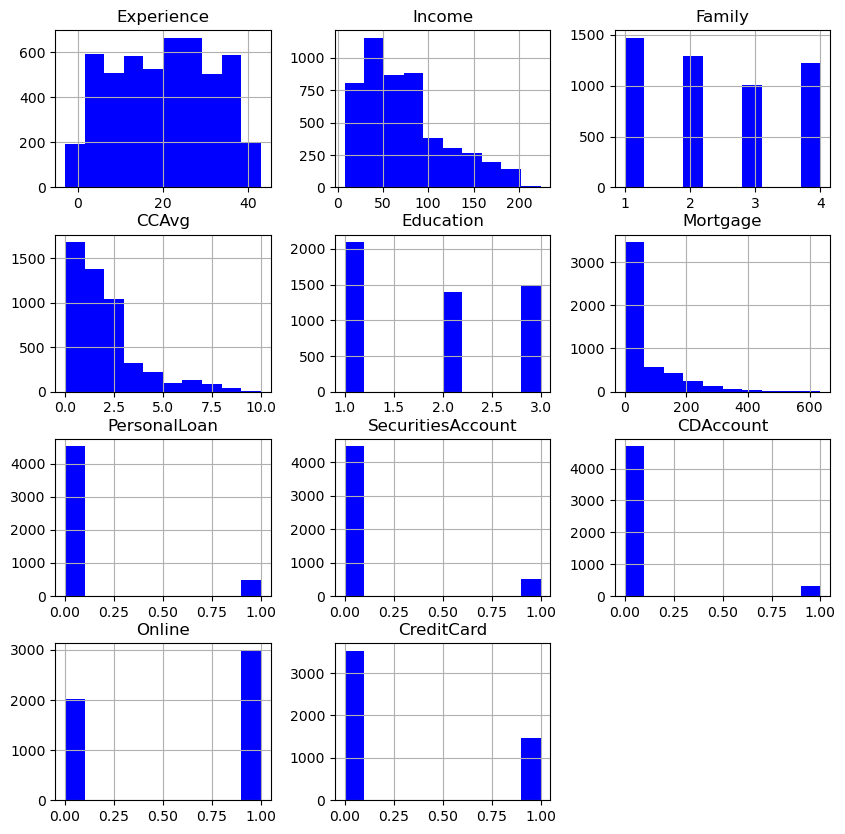

```python
df.hist(bins=10,figsize= (10,10), color='blue')
plt.show()
```

#### The following variables have a right skewed data:

- Income
- Family
- CCAvg
- Mortage
- Personal Loan
- Securities Account
- CDAccount
- Credit Card

#### Having right skewed data means that the mean is greater than the median. The mean overestimates the most common values in a positively skewed distribution.

#### The following variables have a left skewed distribution:

- Online

#### Having a left skewed data means that the mean is less than the median. The mean underestimates the most common values in a negatively skewed distribution.

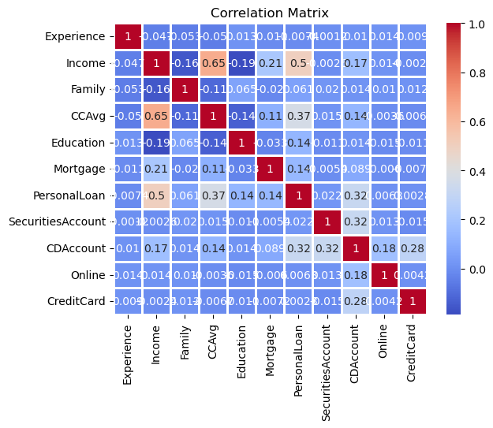

```python
# Correlation Matrix
sns.heatmap(df.corr(), annot=True, cmap="coolwarm",linewidths=2)
plt.title("Correlation Matrix")
plt.show()
```

## 2. Estimate a logistic regression model on the training set. Explain your results in terms of Odds. Then make predictions on the test set using your fitted model. (20 Points)

```python
from sklearn.linear_model import LogisticRegression
from sklearn.model_selection import train_test_split
```

```python
df.columns
```

```
Index(['CustomerID', 'Age', 'Experience', 'Income', 'ZipCode', 'Family',
       'CCAvg', 'Education', 'Mortgage', 'PersonalLoan', 'SecuritiesAccount',
       'CDAccount', 'Online', 'CreditCard'],
      dtype='object')
```

```python
# Split the data into training and testing sets
x = df[['Age', 'Experience', 'Income', 'Family',
       'CCAvg', 'Education', 'Mortgage','SecuritiesAccount',
       'CDAccount', 'Online', 'CreditCard']]
y = df['PersonalLoan']
```

```python
# Split the data into training and testing sets
x_train, x_test, y_train, y_test = train_test_split(x, y, test_size=0.20, random_state=42)

print(x_test.shape)
print(x_train.shape)
print(y_test.shape)
print(y_train.shape)
```

```
(1000, 11)
(4000, 11)
(1000,)
(4000,)
```

```python
train_test_split
# User can get information on train_test_split or any imported function using shift-Tab
# Signature:
# train_test_split(
#     *arrays,
#     test_size=None,
#     train_size=None,
#     random_state=None,
#     shuffle=True,
#     stratify=None,
# )
# Docstring:
# Split arrays or matrices into random train and test subsets.

# Quick utility that wraps input validation,
# ``next(ShuffleSplit().split(X, y))``, and application to input data
# into a single call for splitting (and optionally subsampling) data into a
# one-liner.
```

```
<function sklearn.model_selection._split.train_test_split(*arrays, test_size=None, train_size=None, random_state=None, shuffle=True, stratify=None)>
```

```python
# CREATE THE MODEL
logreg = LogisticRegression(random_state=16, max_iter = 1000000)

# FIT THE DATA
logreg.fit(x_train, y_train)

# PREDICT ON TEST SET
y_pred = logreg.predict(x_test)
```

```python
print('intercept ', logreg.intercept_[0])
print(pd.DataFrame({'coeff': logreg.coef_[0]}, index=x.columns).transpose())
```

```
intercept  -11.648458180312028
            Age  Experience    Income    Family     CCAvg  Education  \
coeff -0.054905    0.065964  0.052176  0.713894  0.102564   1.596503

       Mortgage  SecuritiesAccount  CDAccount    Online  CreditCard
coeff  0.000587          -0.643306   3.320898 -0.547244   -1.042386
```

```python
# Extract the intercept and coefficient values
intercept = logreg.intercept_[0]
coefficients = logreg.coef_[0]

# Convert the intercept to odds
odds_intercept = np.exp(intercept)

# Convert the coefficients to odds
odds_coefficients = np.exp(coefficients)

# Print the results
print('Intercept odds ratio: ', odds_intercept)
print(pd.DataFrame({'Odds ratio': odds_coefficients}, index=x.columns).transpose())
```

```
Intercept odds ratio:  8.73250593769505e-06
                 Age  Experience    Income    Family     CCAvg  Education  \
Odds ratio  0.946575    1.068188  1.053561  2.041928  1.108009   4.935743

            Mortgage  SecuritiesAccount  CDAccount    Online  CreditCard
Odds ratio  1.000587           0.525552  27.685214  0.578542    0.352613
```

```python
logit_reg_pred = logreg.predict(x_test)
logit_reg_proba = logreg.predict_proba(x_test)
logit_result = pd.DataFrame({'actual': y_test,
                             'p(0)': [p[0] for p in logit_reg_proba],
                             'p(1)': [p[1] for p in logit_reg_proba],
                             'predicted': logit_reg_pred })



logit_result.head(10)
```

|  | actual | p(0) | p(1) | predicted |
| --- | --- | --- | --- | --- |
| 1501 | 0 | 0.999736 | 0.000264 | 0 |
| 2586 | 1 | 0.711428 | 0.288572 | 0 |
| 2653 | 0 | 0.973864 | 0.026136 | 0 |
| 1055 | 0 | 0.999796 | 0.000204 | 0 |
| 705 | 0 | 0.998080 | 0.001920 | 0 |
| 106 | 0 | 0.997824 | 0.002176 | 0 |
| 589 | 0 | 0.963894 | 0.036106 | 0 |
| 2468 | 0 | 0.988024 | 0.011976 | 0 |
| 2413 | 0 | 0.991530 | 0.008470 | 0 |
| 1600 | 0 | 0.939629 | 0.060371 | 0 |